# 4. RFID Tutorial: Exercise answers

Gabrielle Davidson - School of Biological Sciences, University of East Anglia

2024-08-15

## 4. Get set up

### Check R packages installed

```r
#load the following packages
library(tidyverse)
library(rmarkdown)
library(dplyr)
library(tidyr)
library(lubridate)
library(ggplot2)
library(stringi) #may not need this
library(magrittr) #may not need this
```

### Download resources necessary for the workshop

Download the resources from **[my github page](https://github.com/DrGLDavidson/RFID-workshop)**

### **4.4 EXERCISE ANSWERS**

```r
#clear the global environment so we don't have any conflicts with the next steps

rm(list = ls(all.names = TRUE))

#choose the appropriate working directory

setwd("F:/RWorkspace/GitHub/RFID-workshop/data/outputFiles")

#call your most recent dataset

df<-read.delim("Masterdf_noRepeats.txt", header=TRUE)
head(df)
```

```
##         date            dateTime Hmsec     ID Event Channel    Dur Clks   Freq
## 1 2022-02-04 2022-02-04 10:01:13   467 c1935    146       0      0   32 126464
## 2 2022-02-04 2022-02-04 11:06:19   516 c1931  15597       0 127943   26      0
## 3 2022-02-04 2022-02-04 11:06:32   770 c1935    147       0      6   39 126208
## 4 2022-02-04 2022-02-04 11:17:36   871 c1935    148       0 105573   51 126464
## 5 2022-02-04 2022-02-04 11:17:40   123 c1935    148       0 121015   27 126208
## 6 2022-02-04 2022-02-04 11:17:48   543 c1931  15598       0      0   39      0
##   Edges Reps Type  TagID_hex feeder dateRinged timeRinged btoRingType   btoID
## 1   264    2    1 01103FC949    F01 09/01/2021      11:03           R AKL0680
## 2   442    1    1 01103F7DB1    F02 03/10/2021      10:30           R AAJ5894
## 3   426    3    1 01103F7DB1    F01 03/10/2021      10:30           R AAJ5894
## 4  1168    5    1 01103F3BED    F01 17/10/2021      10:09           R AAJ5895
## 5   174    1    1 01103F3BED    F01 17/10/2021      10:09           R AAJ5895
## 6   388    3    1 01103FE3B3    F02 07/11/2021      12:15           R AJT8118
##   species pitTYPE age sex wing weight timeSincePreviousVisit
## 1      BT       R   5   M   64   11.7             firstVisit
## 2      GT       R   3   F   73   16.3             firstVisit
## 3      GT       R   3   F   73   16.3             firstVisit
## 4      GT       R   3   M   75   18.5             firstVisit
## 5      GT       R   3   M   75   18.5                      4
## 6      GT       R   3   F   72   18.1             firstVisit
```

```r
names(df)
```

```
##  [1] "date"                   "dateTime"               "Hmsec"
##  [4] "ID"                     "Event"                  "Channel"
##  [7] "Dur"                    "Clks"                   "Freq"
## [10] "Edges"                  "Reps"                   "Type"
## [13] "TagID_hex"              "feeder"                 "dateRinged"
## [16] "timeRinged"             "btoRingType"            "btoID"
## [19] "species"                "pitTYPE"                "age"
## [22] "sex"                    "wing"                   "weight"
## [25] "timeSincePreviousVisit"
```

4.4.1 Create a dataframe of the total visits per individual across the whole of your experiment, irrespective of feeder. (hint: group_by)

4.4.2 Create a new dataframe that excludes individuals that visited less than 5 times. (hint: section 3.5)

4.4.3 rename the column of the number of visits to “totalVisits”.

4.4.4 create a figure of your choice representing the number of visits from your new dataframe.

4.4.5 create a dataframe with a list of birds we consider participants and save it as a csv file.

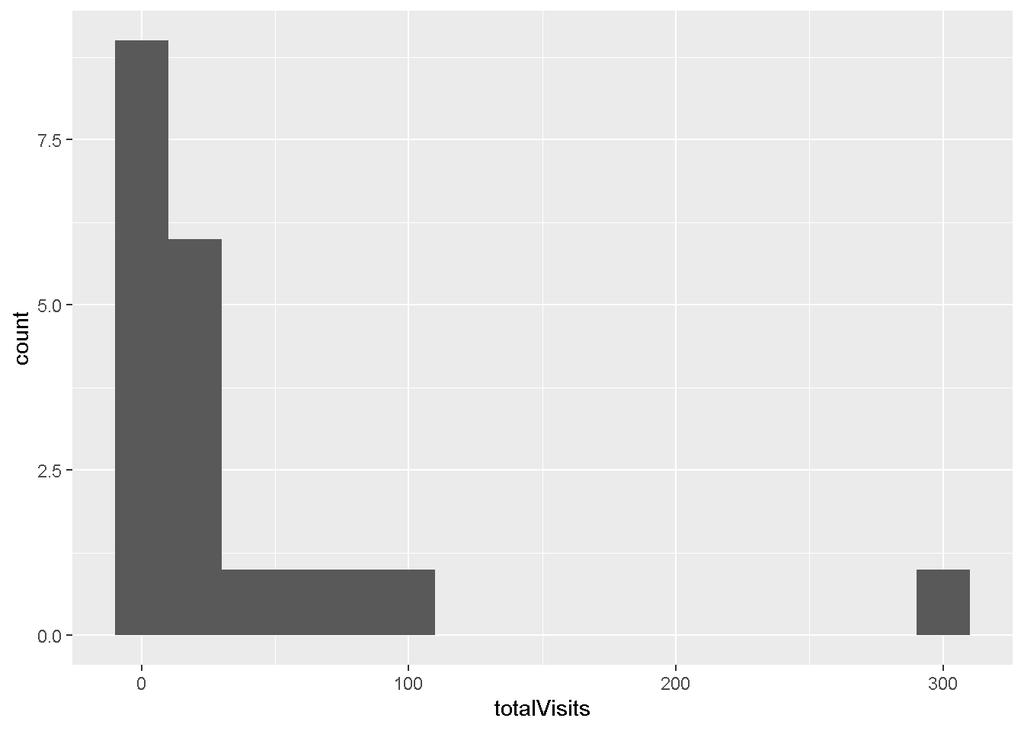

```r
#4.4.1
individualvisits<-df%>%
  count(TagID_hex, sort = TRUE)
#4.4.2
individualvisits2<-individualvisits%>%
  filter(n >5)%>%
  select(TagID_hex,n)

#4.4.3
names(individualvisits2)[names(individualvisits2) == "n"] <- "totalVisits"

#4.4.4 create a figure of your choice representing the number of visits from your new dataframe.
ggplot(individualvisits2, aes(x=totalVisits)) +geom_histogram(binwidth = 20)
```

```r
#4.4.5 create a dataframe with a list of birds we consider participants and save it as a csv file.
participants <- unique(individualvisits2$TagID_hex)

participants<-as.data.frame(participants)
#write.csv(participants, file="FeederExperimentParticipants.csv"))
```

Extra code, not in the exercise, but perhaps useful: how many RFID devices an individual visits

```r
# check how many feeders each individual visited
IDFeeder<-df%>%
  count(feeder, TagID_hex, sort = TRUE)
IDFeeder<-IDFeeder%>%
  count(TagID_hex, sort = TRUE)
summary(IDFeeder$n)
```

```
##    Min. 1st Qu.  Median    Mean 3rd Qu.    Max.
##   1.000   1.000   2.000   2.136   3.000   3.000
```

### 4.5 EXERCISE - Time intervals between visits among individuals

Previously we created a column that indicated how many seconds had passed since an individual’s previous visit per day. A similar approach can be taken to calculate intervals between visits between individuals (i.e. how long has passed since the previous birds’ visit)

4.5.1 clear your global environment

4.5.3 change the datetime column to be a POSIXct class

4.5.4 create a new column that calculates the time difference from the previous row of a dataframe grouped by date and feeder. Dont forget to use the argument arrange() so the timedate is sequential in your dataframe

4.5.5 create a dataframe consisting of individuals that visited a feeder equal or less than 2 second after the previous visitor.

4.5.6 create a dataframe of a list of unique individuals that have landed on a feeder within 2 second of the previous visitor

```r
# 4.5.1
rm(list = ls(all.names = TRUE))

#4.5.2

#choose the appropriate working directory

setwd("F:/RWorkspace/GitHub/RFID-workshop/data/outputFiles")

#call your most recent dataset

df<-read.delim("Masterdf_noRepeats.txt", header=TRUE)

#4.5.3
class(df$dateTime)
```

```
## [1] "character"
```

```r
df$dateTime <- as.POSIXct(df$dateTime)
class(df$dateTime)
```

```
## [1] "POSIXct" "POSIXt"
```

```r
#4.5.4
df1<-df %>%
  arrange(dateTime)%>%
  group_by(date, feeder) %>%
  mutate(timeBetweenID = dateTime - lag(dateTime))%>%
  arrange(dateTime)%>%
  ungroup()

#4.5.5
df1$timeBetweenID <- as.numeric(as.character(df1$timeBetweenID))
class(df1$timeBetweenID)
```

```
## [1] "numeric"
```

```r
df2<-df1%>%
  filter(timeBetweenID <=2)

#4.5.6
twosec<-unique(df2$TagID_hex)
uniqueDisplacers<-as.data.frame(twosec)
```

### 5.4 EXERCISE - Correct and incorrect visits

Imagine feeder01 is rewarded and feeder02 and feeder03 are not rewarded. How would you include a column called “correctChoice” where visits to feeder01 contain the character “Y” and visits to the incorrect feeders contain the character “N”

```r
F01Y<-df%>%
  filter(feeder=='F01')
F01Y<-cbind(F01Y, correctChoice='Y')

F02N<-df%>%
  filter(feeder=='F02')
F02N<-cbind(F02N, correctChoice='N')

F03N<-df%>%
  filter(feeder=='F03')
F03N<-cbind(F03N, correctChoice='N')

df3<-bind_rows(F01Y, F02N, F03N)

#Note that there are other methods, but this method uses approaches we learned in today's workshop. As you enhance your R coding skills you'll inevitably refine your code.
```

# END OF 4. RFID Tutorial: Exercise answers